# Functions and Lists

Lecture 07b  
POLS 6394 · Thursday, October 8

## Today

- Why write a function at all
- The parts of a function, and how to pass it a **column name**
- One decision (`if`) versus a decision for every row (`if_else()`)
- **Lists**: a container for data frames, models, or anything else
- Seeing what your code did: `message()` and tidylog
- Lab: a summary function you’ll reuse

# Why functions

## Copy, paste, edit

When code works for one state, it’s natural to copy it and change the state name. With several copies, it’s easy to miss an edit:

```r
sp |> filter(st == "CA") |> summarize(state = "CA", mean_lib = mean(x = pollib_median))
sp |> filter(st == "NY") |> summarize(state = "NY", mean_lib = mean(x = pollib_median))
sp |> filter(st == "NY") |> summarize(state = "TX", mean_lib = mean(x = pollib_median))
```

The third line labels New York’s result as Texas. The code runs without an error, so you might not notice.

## The rule of three

- If you repeat similar code in three places, consider writing a function.
- Keep the shared calculation in the function and pass the changing values as arguments.

You can change the calculation in one place rather than editing each copy.

## Where you’ll use this

- **Your paper:** the same figure or table for each outcome, region, or subgroup.
- **Problem Set 03**, due October 20: a reusable function and a small iteration task.
- **Part II:** the code Codex writes for you is mostly functions. You’ll need to read them to check them.
- **Iteration:** functions can be applied to every element of a list.

## Our data today

Caughey–Warshaw state policy liberalism, from the Correlates of State Policy Project. One row is a state-year. Higher `pollib_median` means more liberal policy. `pid` is the public’s party identification (higher is more Democratic) and `ideo` its ideology; both are missing for 2012–2014.

```r
library(tidyverse)

sp <- read_csv(file = "Data/state_policy/cspp_states.csv", show_col_types = FALSE) |>
  filter(!is.na(pollib_median))
```

## Ten random rows

```r
set.seed(6394)
sp |>
  slice_sample(n = 10) |>
  select(st, state, region.name, year, pollib_median, pid, ideo)
```

```
# A tibble: 10 × 7
   st    state         region.name  year pollib_median   pid  ideo
   <chr> <chr>         <chr>       <dbl>         <dbl> <dbl> <dbl>
 1 KS    Kansas        midwest      1980          -0.2 -0.05 -0.15
 2 VT    Vermont       northeast    1992           1.4 -0.11 -0.07
 3 MA    Massachusetts northeast    1980           1.5  0.18  0.03
 4 AZ    Arizona       west         1999          -0.7 -0.05 -0.09
 5 IA    Iowa          midwest      2006           0.1  0.01 -0.07
 6 DE    Delaware      south        1993           0.3 -0.17 -0.22
 7 DE    Delaware      south        1982           0.7 -0.04 -0.2
 8 CA    California    west         1981           1.2  0.02 -0.05
 9 TN    Tennessee     south        1993          -0.7  0.08 -0.11
10 TN    Tennessee     south        1979          -0.5  0.17 -0.22
```

Region names are lowercase: `"south"`, not `"South"`.

# The parts of a function

## Name, arguments, body

```r
pct_change <- function(new, old) {
  return(100 * (new - old) / old)
}
```

- `pct_change <-` is the **name**. A function is an object, so you assign it like any other.
- `function(new, old)` lists the **arguments**: the inputs the caller supplies.
- Everything between `{ }` is the **body**. It uses the arguments as if they were ordinary objects.

Running this chunk creates the function. It doesn’t compute anything yet.

## Call it

```r
pct_change(150, 100)
```

```
[1] 50
```

```r
pct_change(new = 80, old = 100)
```

```
[1] -20
```

`return()` sends a value back to the caller and ends that function call. Here it returns the percentage change, which you can print, save, or use in another calculation.

The first call matches arguments **by position**: 150 goes to `new`, 100 to `old`. The second names the arguments explicitly.

## The last-line shorthand

R also returns the last expression automatically. This version gives the same results without `return()`:

```r
pct_change <- function(new, old) {
  100 * (new - old) / old
}

pct_change(new = 80, old = 100)
```

```
[1] -20
```

We’ll usually write `return()` so you can see exactly what comes back.

## Vectors in, vectors out

```r
pct_change(new = c(150, 80), old = c(100, 100))
```

```
[1]  50 -20
```

The arithmetic works on each pair of values in the vectors. The function therefore calculates a percentage change for each pair without a loop.

## Your Turn: your first function

*~4 minutes*

Write `center()`, which subtracts a vector’s mean from every value so the result is centered on zero. Test it on `sp$pid`; `summary()` shows whether the mean is now 0.

```r
center <- function(x) {
  return(___)
}

center(x = sp$pid) |> summary()
```

`pid` is missing for 2012–2014. What do you get if `mean()` doesn’t skip those values? Fix that.

## Defaults

An argument can have a **default**, which applies when the caller leaves it out.

```r
mean_round <- function(x, digits = 2) {
  return(round(x = mean(x = x, na.rm = TRUE), digits = digits))
}

mean_round(x = sp$ideo)
```

```
[1] -0.15
```

```r
mean_round(x = sp$ideo, digits = 1)
```

```
[1] -0.1
```

`digits = 2` sets the default; the second call overrides it. Naming the arguments shows which value is the input and which is a setting. When you pipe, the pipe supplies the first argument, so you don’t name it.

## Changes inside a function stay local

```r
x <- 100

double_it <- function(x) {
  x <- x * 2
  return(x)
}

double_it(x = 5)
```

```
[1] 10
```

```r
x
```

```
[1] 100
```

`double_it(x = 5)` returns 10, but the `x` in your Environment is still 100. Inside the function, `x` is a **local copy** of what you passed, so assigning to it changes only that copy.

## Why keep objects local?

- Reuse names such as `x` or `result` without overwriting your data outside the function.
- Keep temporary calculations out of the Environment pane.
- Use `return()` to send back the result, then save it if you want to keep it.

## A function can return a tibble

Save the pipeline’s tibble in a local object, then return it to the caller.

```r
region_summary <- function(df) {
  result <- df |>
    group_by(region.name) |>
    summarize(mean_lib = mean(x = pollib_median))
  return(result)
}

region_summary(df = sp)
```

```
# A tibble: 4 × 2
  region.name mean_lib
  <chr>          <dbl>
1 midwest       0.0107
2 northeast     1.33
3 south        -0.830
4 west          0.0932
```

## Your Turn: replace the copies

*~5 minutes*

Turn the three copied summaries into one function. Decide which value changes from copy to copy; that’s the argument.

```r
state_summary <- function(df, ___) {
  result <- df |>
    filter(st == ___) |>
    summarize(state = ___, mean_lib = mean(x = pollib_median))
  return(result)
}

state_summary(df = sp, state_abb = "CA")
state_summary(df = sp, state_abb = "TX")
```

The same state argument supplies both the filter and the label.

# Functions over data

## A column name is different

`region_summary()` works for exactly one column. Try making the column an argument:

```r
region_mean <- function(df, yvar) {
  result <- df |>
    group_by(region.name) |>
    summarize(mean = mean(x = yvar, na.rm = TRUE))
  return(result)
}

region_mean(df = sp, yvar = ideo)
```

```
Error in `summarize()`:
ℹ In argument: `mean = mean(x = yvar, na.rm = TRUE)`.
ℹ In group 1: `region.name = "midwest"`.
Caused by error:
! object 'ideo' not found
```

## Why it failed

Inside `summarize()`, dplyr looks up bare names like `ideo` **in the data**. That’s why you never type `sp$ideo` in a pipeline.

But `ideo` passed into a function arrives as an argument. R goes looking for an object called `ideo` in your Environment, finds nothing, and stops.

You need to tell dplyr: this argument holds a column name, so look it up in the data.

## Embrace it: `{{ }}`

Wrap the argument in double braces, which we call **embracing** it, everywhere it touches the data.

```r
region_mean <- function(df, yvar) {
  result <- df |>
    group_by(region.name) |>
    summarize(mean = mean(x = {{ yvar }}, na.rm = TRUE))
  return(result)
}

region_mean(df = sp, yvar = ideo)
```

```
# A tibble: 4 × 2
  region.name    mean
  <chr>         <dbl>
1 midwest     -0.164
2 northeast   -0.0381
3 south       -0.198
4 west        -0.142
```

## One function, any column

```r
region_mean(df = sp, yvar = pollib_median)
```

```
# A tibble: 4 × 2
  region.name    mean
  <chr>         <dbl>
1 midwest      0.0107
2 northeast    1.33
3 south       -0.830
4 west         0.0932
```

```r
region_mean(df = sp, yvar = pid)
```

```
# A tibble: 4 × 2
  region.name     mean
  <chr>          <dbl>
1 midwest     -0.00583
2 northeast    0.0711
3 south        0.110
4 west        -0.0308
```

## Values versus columns

| Argument | Example | Inside the function |
| --- | --- | --- |
| A **value**, such as a state | `"CA"` | Use it as is: `st == state_abb` |
| A **column name** | `pollib_median` | Embrace it: `{{ yvar }}` |

For these functions, pass state names in quotes. Wrap column arguments in `{{ }}` inside `filter()`, `summarize()`, or `aes()`.

## A plot function

`{{ }}` works inside `aes()` too.

```r
policy_trend <- function(df, yvar, state_abb) {
  result <- df |>
    filter(st == state_abb) |>
    ggplot(aes(x = year, y = {{ yvar }})) +
    geom_line(color = "steelblue", linewidth = 1) +
    geom_point(color = "steelblue", size = 1.5) +
    labs(title = paste(state_abb, "policy trend over time"),
         x = NULL) +
    theme_minimal()
  return(result)
}
```

`paste()` combines the state and the rest of the title into one string. ggplot already uses the mapped column name for the y-axis label. We can replace it with a clearer label using `labs(y = ...)`.

## One function, many plots

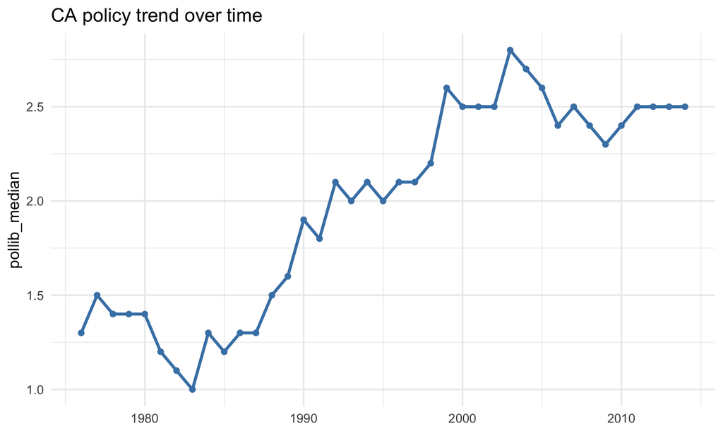

```r
policy_trend(
  df = sp, yvar = pollib_median,
  state_abb = "CA"
)
```

Use `policy_trend(df = sp, yvar = pollib_median, state_abb = "TX")` to draw the Texas trend.

## Guided practice: add a subtitle

*~2 minutes*

Add a `subtitle` argument with the default `"State policy over time"`, and use it in `labs()`.

```r
policy_trend <- function(df, yvar, state_abb, ___) {
  result <- df |>
    filter(st == state_abb) |>
    ggplot(aes(x = year, y = {{ yvar }})) +
    geom_line(color = "steelblue", linewidth = 1) +
    geom_point(color = "steelblue", size = 1.5) +
    labs(title = paste(state_abb, "policy trend over time"),
         subtitle = ___, x = NULL) +
    theme_minimal()
  return(result)
}
```

## Guided practice: call it two ways

Once your new `policy_trend()` runs, call it relying on the default, then with a subtitle of your own.

```r
policy_trend(df = sp, yvar = pollib_median, state_abb = "NY")
policy_trend(
  df = sp, yvar = pollib_median, state_abb = "NY",
  subtitle = "New York, 1976–2014"
)
```

## Change the outcome and title

The default title describes policy. When you change the outcome, update the title and axis label too. Filter missing `pid` values first, then use `+ labs()` to replace the plot text. The function itself stays the same.

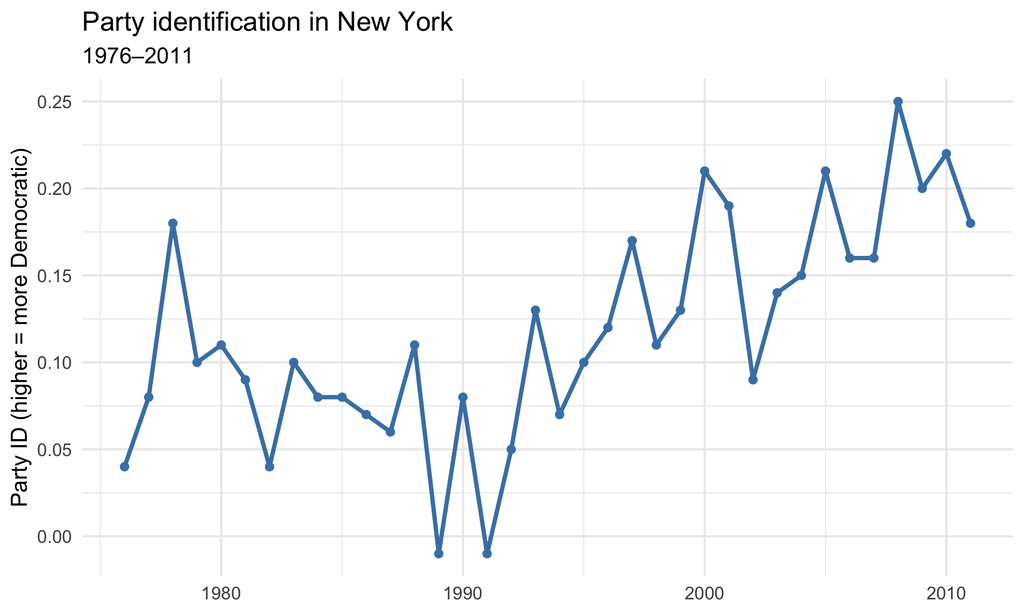

```r
sp |>
  filter(!is.na(pid)) |>
  policy_trend(yvar = pid, state_abb = "NY") +
  labs(title = "Party identification in New York",
       subtitle = "1976–2011",
       y = "Party ID (higher = more Democratic)")
```

# One decision or many

## `if` makes one decision

```r
lean_label <- function(score) {
  if (score > 0) {
    return("liberal")
  } else {
    return("conservative")
  }
}

lean_label(score = 2.5)
```

```
[1] "liberal"
```

```r
lean_label(score = -0.8)
```

```
[1] "conservative"
```

R checks the condition in `( )`. If it’s `TRUE`, R runs the first `{ }` block; otherwise it runs the block after `else`.

## `if` takes one value, not a column

```r
lean_label(score = sp$pollib_median)
```

```
Error in `if (score > 0) ...`:
! the condition has length > 1
```

`if` needs a single `TRUE` or `FALSE`. A column has hundreds of values, so R stops.

## `if_else()` decides for every row

You’ve used `if_else()` and `case_when()` inside `mutate()` before. They’re **vectorized**: one decision per row.

```r
sp |>
  filter(year == 2010) |>
  mutate(lean = if_else(pollib_median > 0, "liberal", "conservative")) |>
  count(lean)
```

```
# A tibble: 2 × 2
  lean             n
  <chr>        <int>
1 conservative    26
2 liberal         22
```

## The rule of thumb

- **`if ()`**: one decision about one value, such as an argument. It controls what a function does next.
- **`if_else()` / `case_when()`**: a decision for every row of a column. They go inside `mutate()`.

If R says “the condition has length > 1”, the condition contains multiple values. You probably wanted `if_else()`.

# Lists

## A list holds anything

A vector holds values of one type. A **list** holds anything: vectors of different lengths, data frames, models. You made one in 06b, when `list()` collected two models for `modelsummary()`.

```r
ca <- list(
  state = "CA",
  years = c(1980, 2000, 2014),
  scores = c(1.4, 2.5, 2.5)
)
ca
```

```
$state
[1] "CA"

$years
[1] 1980 2000 2014

$scores
[1] 1.4 2.5 2.5
```

## Getting things out

```r
ca$state
```

```
[1] "CA"
```

```r
ca[["years"]]
```

```
[1] 1980 2000 2014
```

```r
ca["years"]
```

```
$years
[1] 1980 2000 2014
```

- `$` and `[[ ]]` give you the element itself: here a character value and a numeric vector.
- `[ ]` gives you a smaller **list** containing that element. Notice the `$years` header in the output.

Use `[[ ]]` or `$` unless you want a list back.

## A function that reads one file

Data may arrive in separate files for each region, year, or survey wave. This function reads one region’s file and prints its path.

```r
read_region <- function(region) {
  path <- paste0("Data/state_policy/regions/", region, ".csv")
  message("Reading ", path)
  return(read_csv(file = path, show_col_types = FALSE))
}
```

- `paste0()` is `paste()` with no spaces between the pieces, which is what a file path needs.
- `message("Reading ", path)` prints `Reading` followed by the file path, so you can see which file the function is processing. It doesn’t change the returned data.

## A list of data frames

```r
region_list <- list(
  midwest = read_region(region = "midwest"),
  northeast = read_region(region = "northeast"),
  south = read_region(region = "south"),
  west = read_region(region = "west")
)
```

```
Reading Data/state_policy/regions/midwest.csv
```

```
Reading Data/state_policy/regions/northeast.csv
```

```
Reading Data/state_policy/regions/south.csv
```

```
Reading Data/state_policy/regions/west.csv
```

```r
names(region_list)
```

```
[1] "midwest"   "northeast" "south"     "west"
```

Each list element contains a data frame. `region_list$south` retrieves the South’s data.

## Stack tibbles with `bind_rows()`

`bind_rows()` stacks rows vertically and lines up columns **by name**, not position. If a column occurs in only one tibble, it keeps that column and fills the other rows with `NA`. It doesn’t overwrite existing rows.

Here are two small tibbles with made-up values. Only the second has a `year` column:

```r
first <- tibble(st = "CA", pid = 0.1)
second <- tibble(year = 2000, st = "TX", pid = -0.1)

bind_rows(first, second)
```

```
# A tibble: 2 × 3
  st      pid  year
  <chr> <dbl> <dbl>
1 CA      0.1    NA
2 TX     -0.1  2000
```

## Stack them

The files have no region column; the region is only in each file’s name. `bind_rows()` stacks the list into one data frame, and `.id = "region"` turns the list names into a column.

```r
regions <- bind_rows(region_list, .id = "region")

regions |>
  count(region)
```

```
# A tibble: 4 × 2
  region        n
  <chr>     <int>
1 midwest     468
2 northeast   351
3 south       624
4 west        429
```

## Ten stacked rows

```r
set.seed(6394)
regions |>
  slice_sample(n = 10)
```

```
# A tibble: 10 × 7
   region    st    state          year pollib_median   pid  ideo
   <chr>     <chr> <chr>         <dbl>         <dbl> <dbl> <dbl>
 1 northeast MA    Massachusetts  1980           1.5  0.18  0.03
 2 west      NV    Nevada         1992          -0.6 -0.09  0.01
 3 northeast NJ    New Jersey     1980           1.9  0.11 -0.06
 4 midwest   IN    Indiana        1999          -0.6  0.01 -0.16
 5 midwest   OH    Ohio           2006          -0.1  0.06 -0.15
 6 midwest   MO    Missouri       1993          -0.4  0.05 -0.17
 7 midwest   MO    Missouri       1982          -0.4  0.04 -0.12
 8 midwest   KS    Kansas         1981          -0.3  0.17  0.06
 9 west      CO    Colorado       1993          -0.4  0.01 -0.12
10 west      CO    Colorado       1979           0.2 -0.08 -0.03
```

## Model results as a tibble

`lm()` returns a model object, not a data set you can filter or stack. The **broom** package’s `tidy()` turns its coefficients into a tibble, with one row per term:

- `term`: the intercept or predictor name.
- `estimate` and `std.error`: the coefficient and its standard error.
- `statistic` and `p.value`: the t statistic and its p-value.

In the next exercise, `models[["both"]]` retrieves one model from a list, and `broom::tidy()` extracts its results without fitting it again.

## Your Turn: a list of models

*~5 minutes*

Fit three models of policy liberalism, keep them in a named list, and use `broom::tidy()` to inspect the one with both predictors.

```r
models <- list(
  pid = lm(formula = pollib_median ~ pid, data = regions),
  ideo = lm(formula = pollib_median ~ ___, data = regions),
  both = lm(formula = pollib_median ~ ___, data = regions)
)

broom::tidy(models[[___]])
```

Pull out the model with both predictors.

## Repeated function calls

Reading all four files required four calls to `read_region()`. Inspecting all three models would require three calls to `broom::tidy()`.

`map()` can apply a function to every element of a list:

```r
map(c("midwest", "northeast", "south", "west"), read_region)
map(models, broom::tidy)
```

## A tidylog reminder

Load tidylog after the tidyverse to report what each verb changes. `warn.conflicts = FALSE` skips the list of replaced functions.

```r
library(tidylog, warn.conflicts = FALSE)
```

In the lab, tidylog reports the pipeline’s changes; your own `message()` reports the number of groups.

## Save functions in an R script

*~8–10 minutes.*

To use these functions in another document, save their definitions in a plain `.R` file and load it with `source()`.

1. **File → New File → R Script.** Paste `policy_trend()` and `region_mean()` into it.
2. Save it as `R/07b-functions.R`. Create the `R` folder when RStudio asks where to save.
3. In the workbook, run the next chunk.

## Load functions with `source()`

```r
rm(policy_trend, region_mean)
source("R/07b-functions.R")
policy_trend(df = sp, yvar = pollib_median, state_abb = "OH")
```

- `rm()` deletes the two functions from your Environment, so you can tell the next line really loads them.
- `source()` runs every line of the `.R` file, which defines both functions again.
- The path is relative to the workbook, like your `Data/` paths.

# Lab

## Lab: a summary function you’ll reuse

*~20 minutes total.* Spend 5–10 minutes starting the workbook lab in class; finish by 7:00 PM Monday.

1. **`tidy_summary()`** (worked): run it on at least two columns of `regions` to get counts, means, medians, and SDs by region.
2. **Report the number of groups**: use `if` and `message()` to report how many groups there are, with a note when there’s only one.
3. **A list of summaries**: summarize three columns, keep the results in a named list, and stack them with `bind_rows()`.

## Before Next Class

Save, render, inspect your changes, commit, push, and confirm the commit on GitHub. If unfinished code stops the render, put `#| eval: false` back on that chunk and still push.

- **By 7:00 PM Monday, October 12:** finish the lab and push.
- **Tuesday, October 13, 10:00 AM:** Problem Set 02 is due.
- **Thursday, October 15:** your CV and website both render.
- Optional reference: *R for Data Science* (2e), chapter 25, “Functions.”

# If Time Remains

## Extension 1: a vectorized classifier

*~10 minutes.*

`lean_label()` used `if`, so it took one value at a time. Write `policy_tier()` with `case_when()` so it works on a whole column and inside `mutate()`. Use the same cutoffs on both sides of zero.

```r
policy_tier <- function(score) {
  result <- case_when(
    score > 1.5 ~ "very liberal",
    score > 0 ~ ___,
    score > ___ ~ "conservative",
    .default = "very conservative"
  )
  return(result)
}
```

## Extension 1: use it on the data

```r
sp |>
  filter(year == 2010) |>
  mutate(tier = policy_tier(score = pollib_median)) |>
  tidy_summary(group_var = tier, yvar = pid)
```

Your function goes inside `mutate()`, and its result becomes the group for `tidy_summary()`. Which tier has the most Democratic public? Is that what you expected?